# Project Assignment

BM Molopyane

2022-11-09

## Assessing the impact of different imputations in analytic outcomes

```r
setwd("c:/Users/Molopyane/Documents/datasciencecoursera/Course 5 Reproducible Research/Week 2/Course Project 1/repdata_data_activity")

readings <- read.csv("activity.csv")
```

To enable us to perform proper calculations we will then convert the date from the initial classification of “character”

```r
readings$date<- as.Date(readings$date, "%Y-%m-%d")
sapply(readings,class)
```

```
##     steps      date  interval
## "integer"    "Date" "integer"
```

sapply is executed to affirm the transformation

It is vital to be aware the data you are working with, the first thing is to know if there are null values

```r
NAs <- as.data.frame(which(is.na(readings$steps)))
NAss<- nrow(NAs)
NAss
```

```
## [1] 2304
```

```r
Zeros <- as.data.frame(which(readings$steps == 0))
Positives <- as.data.frame(which(readings$steps > 0))

Counts <- cbind( "NAs"= nrow(NAs), "Zeros"= nrow(Zeros),
                 "Positive" = nrow(Positives))
Counts
```

```
##       NAs Zeros Positive
## [1,] 2304 11014     4250
```

We then see that there are 2304 Null values that should be considered at the back of your mind

We now prepare the data for plotting!

```r
y<- aggregate(steps~date, readings ,sum)
means   <- aggregate(steps~date, readings, mean, na.rm = TRUE)
medians <- aggregate(steps~date, readings, median, na.rm = TRUE)
```

A simple way to visualize the nature of the steps taken is through Histograms. The first histogram shows the range with the highest number of steps taken each day while the second histogram shows the average number of steps taken a day

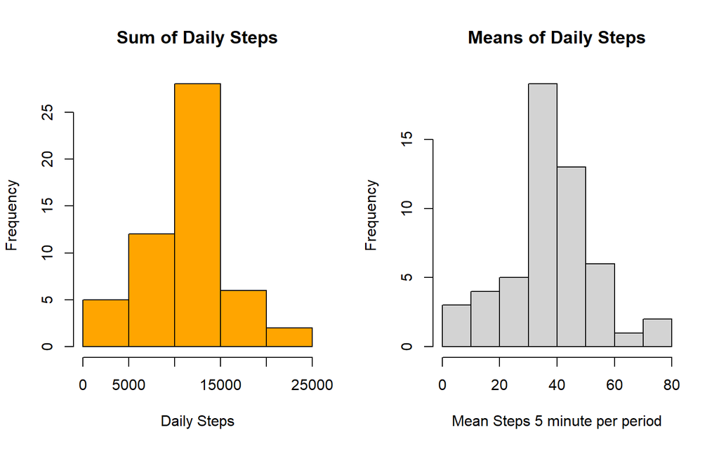

```r
par( mfrow = c(1,2))
hist(y$steps, xlab = "Daily Steps", main = "Sum of Daily Steps", col = "orange" )
hist(means$steps, xlab = "Mean Steps 5 minute per period", main = "Means of Daily Steps")
```

In most cases the user take between 10 000 and 15 000 steps a day and on average 30 to 40 steps per 5 minute interval

Now to see which interval are most steps taken

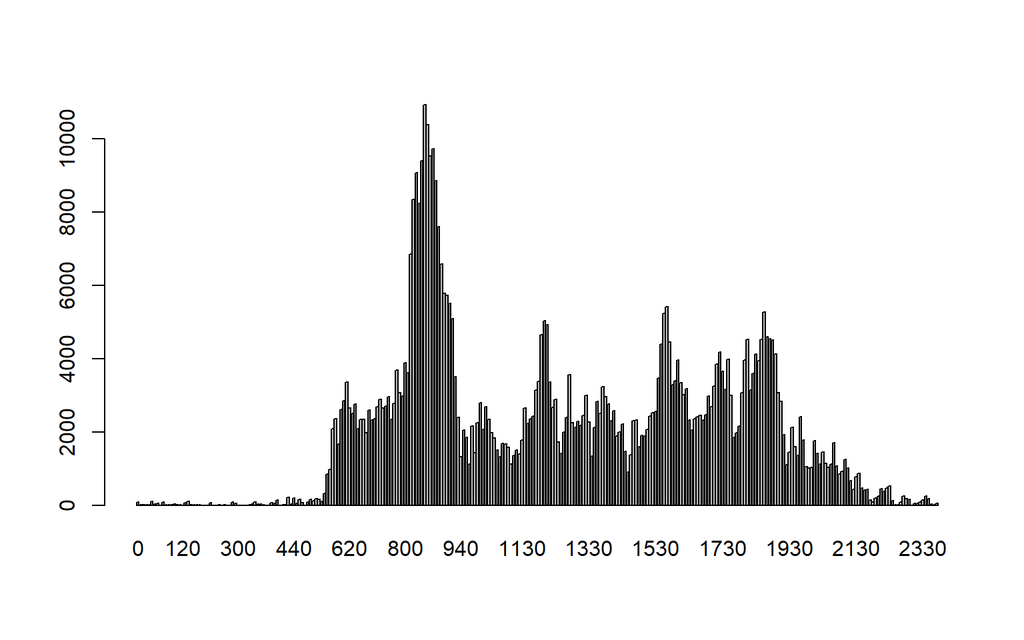

```r
intervals_y <- aggregate(steps~interval, readings, sum)
par( mfrow = c(1,1))
barplot(height = intervals_y$steps, names.arg = intervals_y$interval)
```

the plot shows that most steps happen somewhere between 8 am and 8:50 but we would like a more accurate time

```r
tti<-intervals_y[which(intervals_y[,"steps"]==max(intervals_y$steps)),]
tti
```

```
##     interval steps
## 104      835 10927
```

thus most steps happen in 835, 10927 in the morning

Now let us see if there is a difference between what happen during the week and on weekends

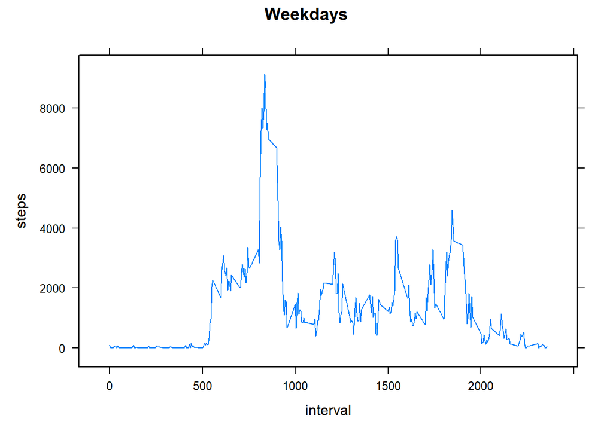

```r
readings$days<-weekdays(readings$date)
days<- c("Monday" ,"Tuesday", "Wednesday", "Thursday", "Friday")
weekends<- c("Saturday", "Sunday")

daysteps     <- readings[which(readings[,"days"] %in% days), ]
weekendsteps <- readings[which(readings[,"days"] %in% weekends),]

intervals_weekdays <- aggregate(steps~interval, daysteps , sum)
intervals_weekends <- aggregate(steps~interval, weekendsteps , sum)

library(lattice)
par(mfrow = c(1,2))
xyplot(steps~interval, data = intervals_weekdays, type = "l", main = "Weekdays")
```

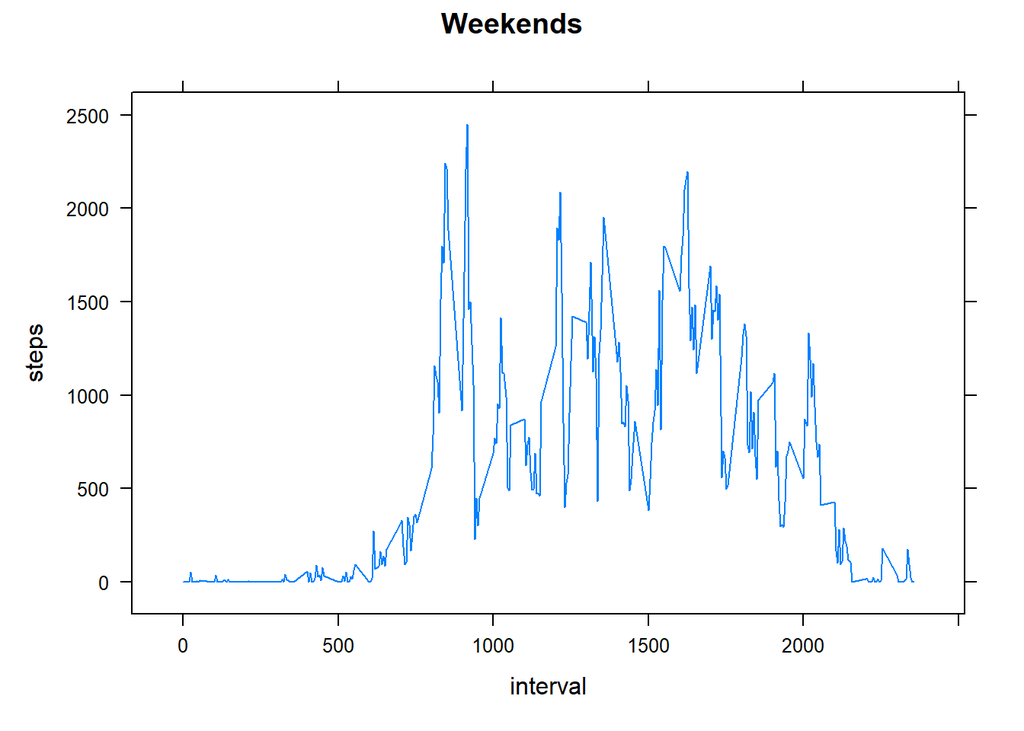

```r
xyplot(steps~interval, data = intervals_weekends, type = "l", main = "Weekends")
```

Let us see what happens when we fill in the null values with the median

The Histograms then take on the following shapes

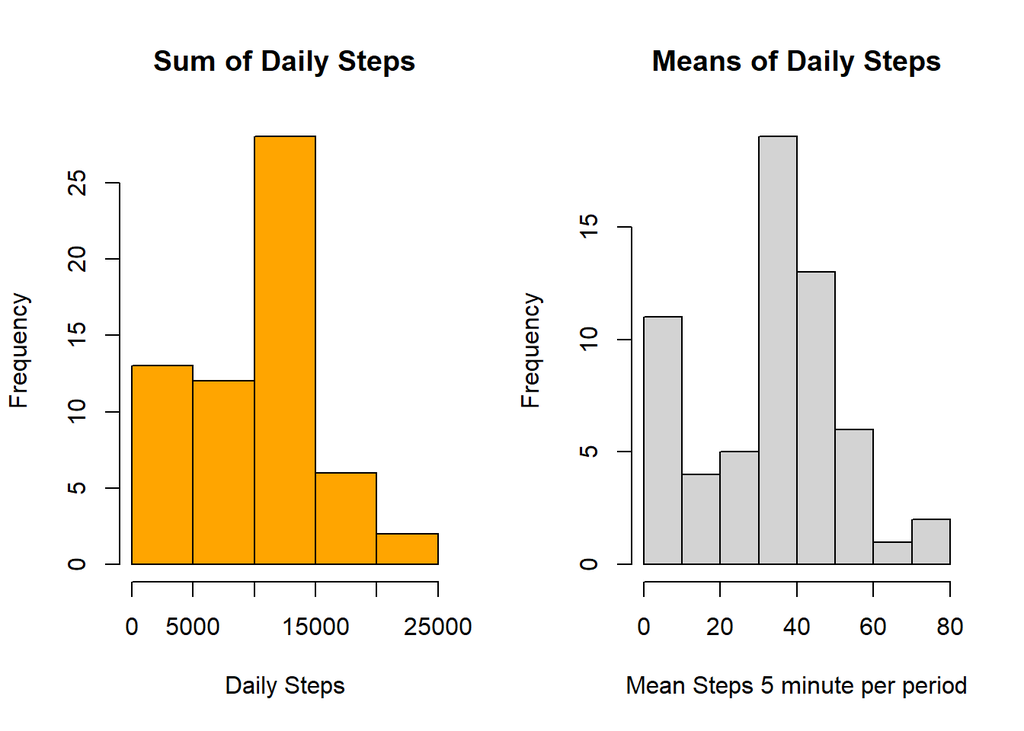

```r
par( mfrow = c(1,2))
hist(median_y1$steps, xlab = "Daily Steps", main = "Sum of Daily Steps", col = "orange" )
hist(means1$steps, xlab = "Mean Steps 5 minute per period", main = "Means of Daily Steps" )
```

As for the barplot for the cumulative interval steps!

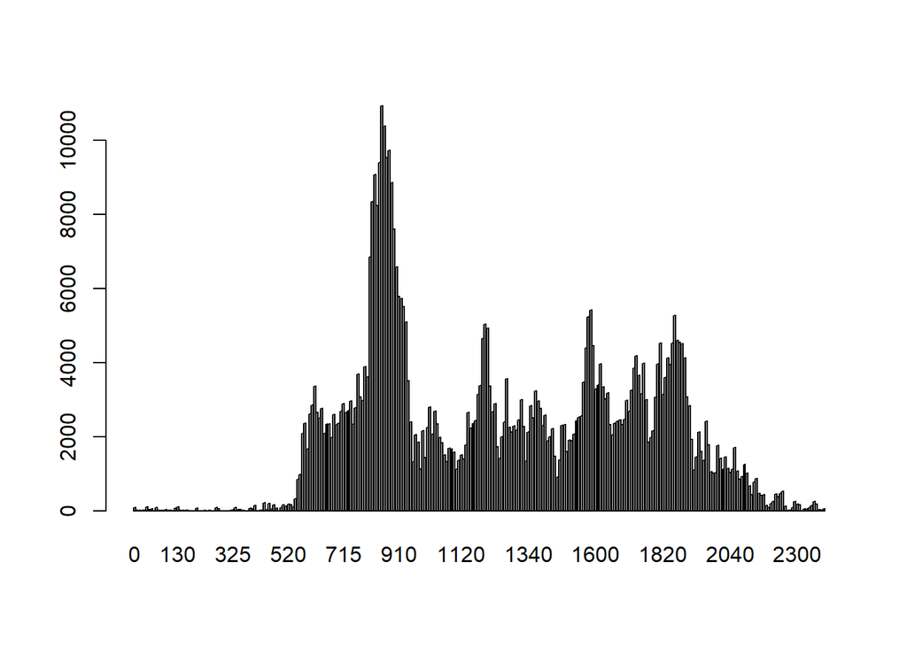

```r
intervals_y1 <- aggregate(steps~interval, readings1, sum)
par( mfrow = c(1,1))
barplot(height = intervals_y1$steps, names.arg = intervals_y1$interval)
```

And the interval with highest number of steps

```
##     interval steps
## 104      835 10927
```

Weekend and weekly variations are given as

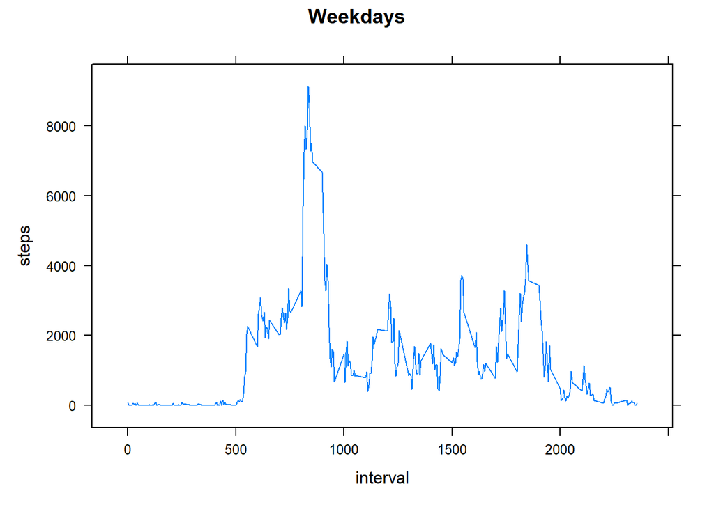

```r
readings1$days<-weekdays(readings1$date)
days<- c("Monday" ,"Tuesday", "Wednesday", "Thursday", "Friday")
weekends<- c("Saturday", "Sunday")

daysteps1     <- readings1[which(readings1[,"days"] %in% days), ]
weekendsteps1 <- readings1[which(readings1[,"days"] %in% weekends),]

intervals_weekdays1 <- aggregate(steps~interval, daysteps1 , sum)
intervals_weekends1 <- aggregate(steps~interval, weekendsteps1 , sum)

library(lattice)

par(mfrow = c(1,2))
xyplot(steps~interval, data = intervals_weekdays1, type = "l", main ="Weekdays")
```

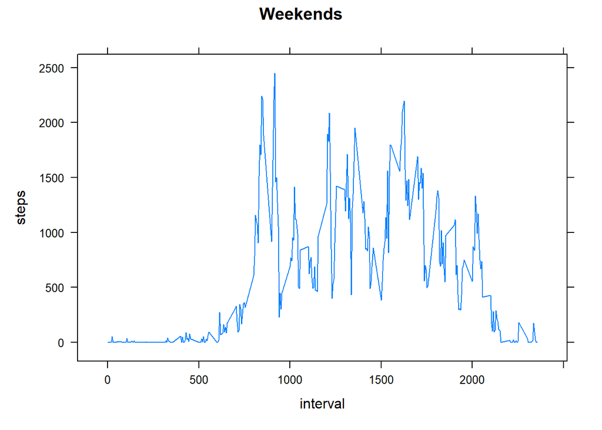

```r
xyplot(steps~interval, data = intervals_weekends1, type = "l", main ="Weekends")
```

Lastly we observe what happens when the null values are filled in with the mean!

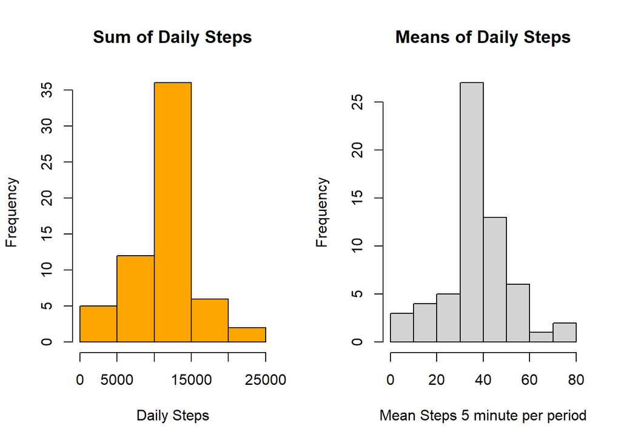

The barplot is!

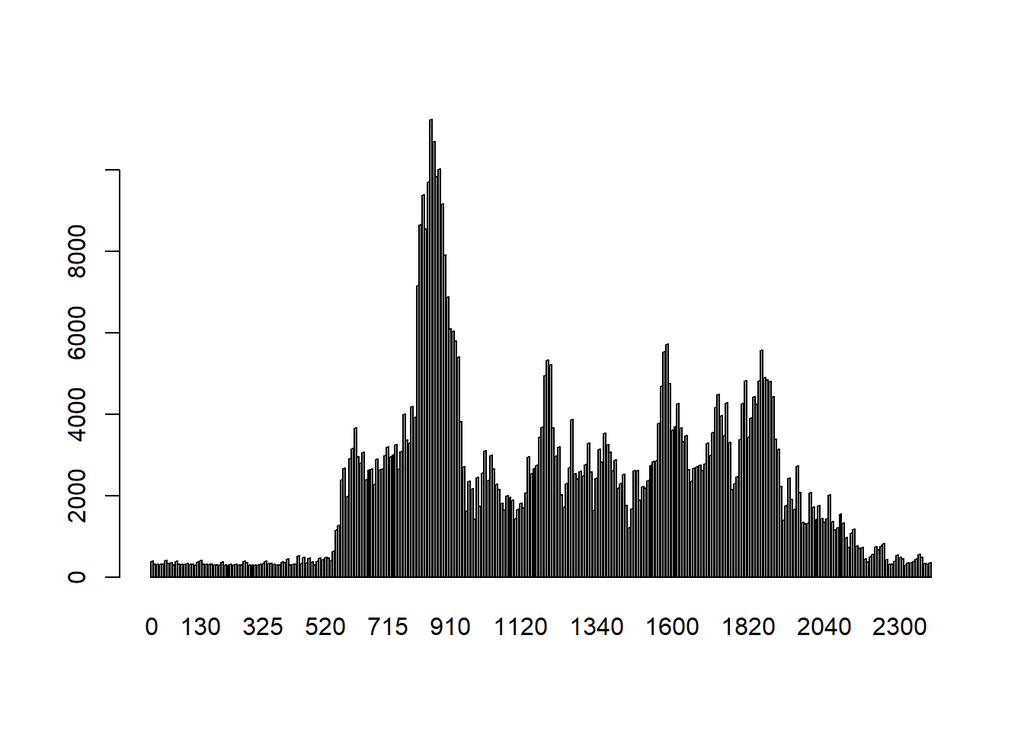

And the highest number of steps occur in

```
##     interval    steps
## 104      835 11226.06
```

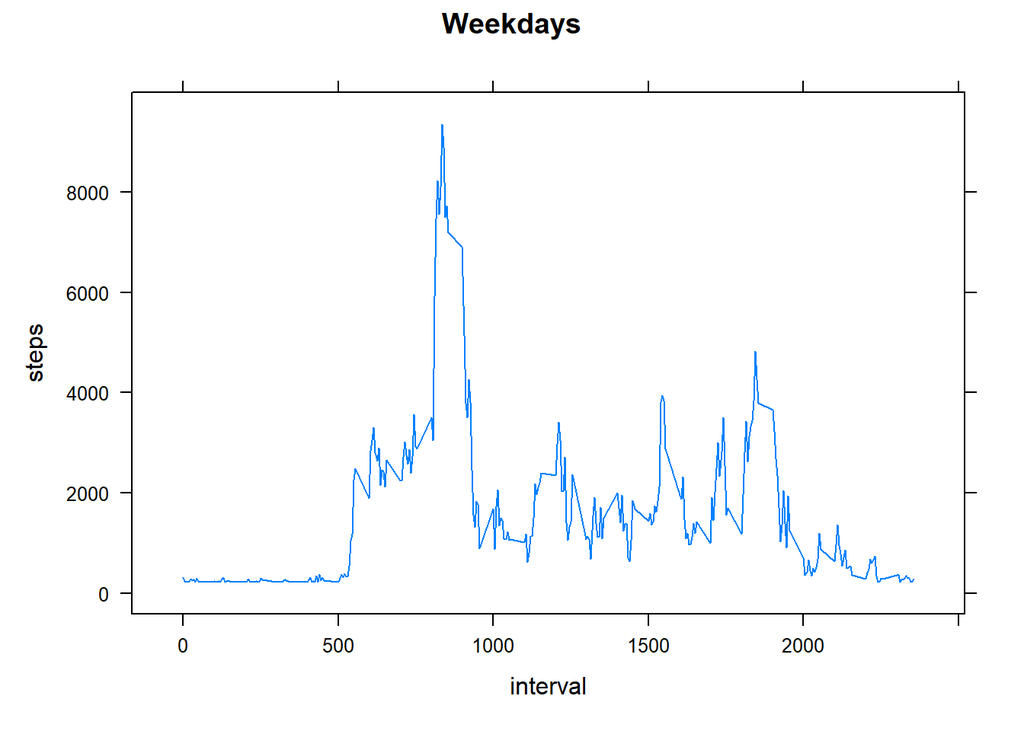

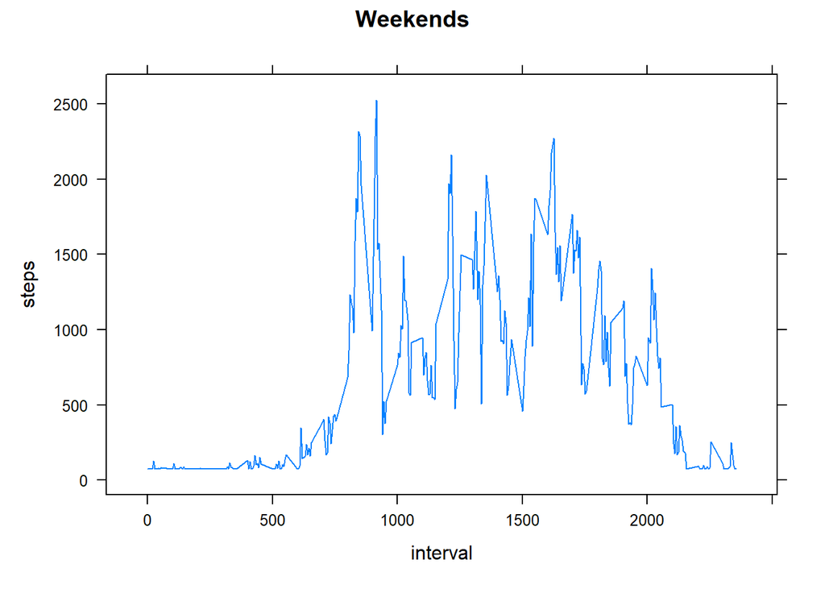

Finally lets group together the graphs to see if there are any differences in the imputation methods

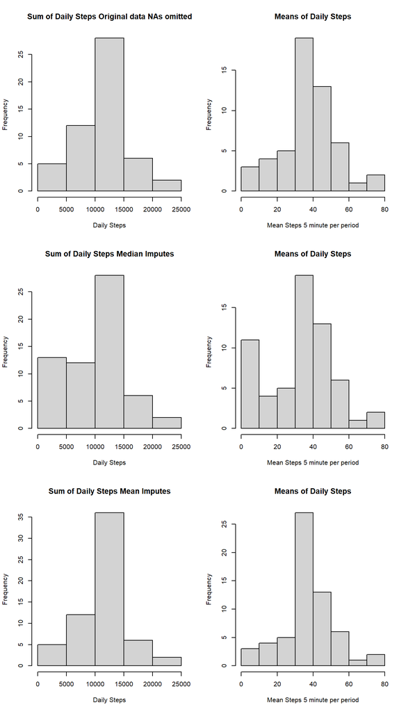

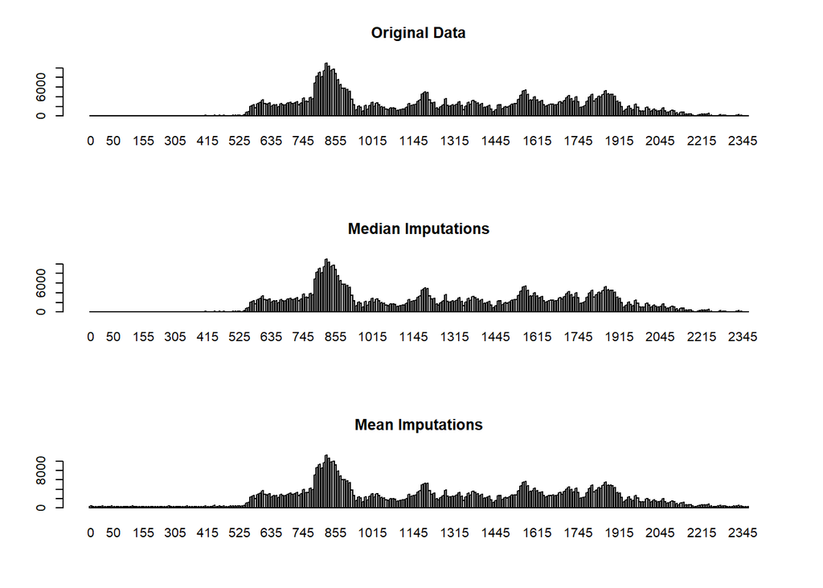

```r
#Interval Histograms
par(mfrow = c(3,1), oma = c(0,0,0,1))
barplot(height = intervals_y$steps, names.arg = intervals_y$interval, main = "Original Data" )
barplot(height = intervals_y1$steps, names.arg = intervals_y1$interval, main = "Median Imputations")
barplot(height = intervals_y2$steps, names.arg = intervals_y2$interval, main = "Mean Imputations")
```

We realize that in certain places the data where the mean imputation is applied is increased slightly

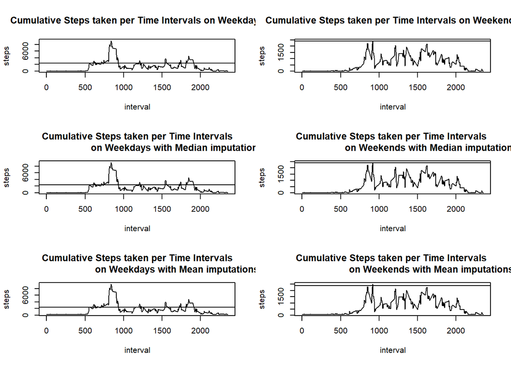

```r
# Day Comparisons
par(mfrow = c(3,2))
#Initial

with(intervals_weekdays, plot(interval, steps, type = "l",
       main = "Cumulative Steps taken per Time Intervals on Weekdays"))
abline( h = 2400)

with(intervals_weekends,plot(interval, steps, type = "l",
       main = "Cumulative Steps taken per Time Intervals on Weekends"))
abline( h = 2400)

# Median
with(intervals_weekdays1, plot(interval, steps, type = "l",
                              main = "Cumulative Steps taken per Time Intervals
                              on Weekdays with Median imputations"))
abline( h = 2400)

with(intervals_weekends1,plot(interval, steps, type = "l",
                             main = "Cumulative Steps taken per Time Intervals
                             on Weekends with Median imputations"))
abline( h = 2400)

#Mean
with(intervals_weekdays2, plot(interval, steps, type = "l",
                               main = "Cumulative Steps taken per Time Intervals
                              on Weekdays with Mean imputations"))
abline( h = 2400)
with(intervals_weekends2,plot(interval, steps, type = "l",
                              main = "Cumulative Steps taken per Time Intervals
                             on Weekends with Mean imputations"))
abline( h = 2400)
```

In a larger scale the data for all imputations portray a similar story and thus although the means have an implication in certain medians, overall the pattern remains the same

WE Will leave the rest to you hope you enjoyed the ride and see that out of all this movement is important and somehow the person walked the most in the morning you’ll decide why!